# Vanilla KNN

# Predictions

That’s a really uncomfortable way to store the results of the model! Let’s try something else. We use the `pred_y` to be consistent with `tidymodels` syntax:

```r
# this should extract the predicted classes
pred_y <-
  model_knn %>%
  as_tibble() %>%
  rename(.pred_y = value)
```

With `attr(<model_name>, 'prob')` we can extract the probabilities associated to each class:

[output not shown]

[output cut: 990 more lines]

The final data should then be:

```r
pred_knn <-
  pred_y %>%
  bind_cols(pred_probabilities)

pred_knn
```

| .pred_y | .pred_prob |
| --- | --- |
| 0 | 0.6666667 |
| 0 | 0.6666667 |
| 0 | 0.6666667 |
| 0 | 0.7333333 |
| 0 | 0.7333333 |
| 0 | 0.7333333 |
| 0 | 0.7333333 |
| 0 | 0.8000000 |
| 0 | 0.8666667 |
| 0 | 0.9333333 |

[output cut: 990 more lines]

However, there seems to be a problem: to which class is `.pred_prob` referred to?

[output not shown]

[output cut: 990 more lines]

This is a bit problematic: the `.pred_prob` column indicates the predicted probability of *that* class. As `tidymodels` paradigm suggests, it might be better to split the column in two and report the predicted probabilities as separate values.

```r
predictions_knn <-
  pred_knn %>%
  mutate(
    .pred_1 = ifelse(.pred_y == 1, .pred_prob, 1 - .pred_prob),
    .pred_0 = ifelse(.pred_y == 0, .pred_prob, 1 - .pred_prob)
  ) %>%
  select(-.pred_prob)

predictions_knn
```

| .pred_y | .pred_1 | .pred_0 |
| --- | --- | --- |
| 0 | 0.33333333 | 0.6666667 |
| 0 | 0.33333333 | 0.6666667 |
| 0 | 0.33333333 | 0.6666667 |
| 0 | 0.26666667 | 0.7333333 |
| 0 | 0.26666667 | 0.7333333 |
| 0 | 0.26666667 | 0.7333333 |
| 0 | 0.26666667 | 0.7333333 |
| 0 | 0.20000000 | 0.8000000 |
| 0 | 0.13333333 | 0.8666667 |
| 0 | 0.06666667 | 0.9333333 |

[output cut: 990 more lines]

Normally, we would proceed with `yardstick` to evaluate the performance of the model… if only we had the test data’s classes!

# More plotting

The `ESL.mixture` contains the lattice points coordinates, i.e. the coordinates of the backgound layer with all of the dots, and create the corresponding grid:

```r
px1 <- ESL.mixture$px1
px2 <- ESL.mixture$px2
```

We can then transform our predictions into a matrix with the same size as the dimensions specified by the lengths of the lattice points’ grid. In this way, we will plot the predicted classes’ probabilities.

The object we want to draw is a sort of heat map, with red dots if a point has been assigned to 1, else blue. This means that we want to color code the probability of assigning that class using a threshold. To do so, we will need to create a column via an `ifelse()` condition:

```
ifelse(.pred_y == 1, .pred_prob, 1 - .pred_prob)
```

To make a plot out of this without `ggplot()` requires intense googling of unexplicative parameters:

```r
# my guess: parameters(margins = < 2 from each side >)
par(mar = rep(2,4))
# contour line
contour(px1, px2, matrix_knn, levels=0.5,
        main = "15-nearest neighbours", axes=FALSE)
# add points
points(x, col=ifelse(y==1, "coral", "cornflowerblue"))
```

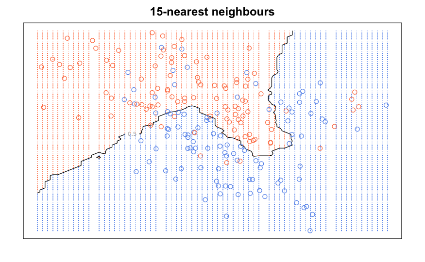

```r
# add grid
points(lattice_grid,
       # the point symbol is pch (WTF?!)
       pch=".",
       # googled it, this is Character Expansion Ratio (...)
       cex=1.2,
       col=ifelse(predictions_knn$.pred_1 > 0.5, "coral", "cornflowerblue"))
box()
```